# week4-3.EDA_2Hypothesis

### 1. 마을의 범죄율에 가장 큰 영향을 미치는 faature는 무엇일까?

#### Attribute Information

- Input features in order:
- 1) CRIM: per capita crime rate by town
- 2) ZN: proportion of residential land zoned for lots over 25,000 sq.ft.
- 3) INDUS: proportion of non-retail business acres per town
- 4) CHAS: Charles River dummy variable (1 if tract bounds river; 0 otherwise)
- 5) NOX: nitric oxides concentration (parts per 10 million) [parts/10M]
- 6) RM: average number of rooms per dwelling
- 7) AGE: proportion of owner-occupied units built prior to 1940
- 8) DIS: weighted distances to five Boston employment centres
- 9) RAD: index of accessibility to radial highways
- 10) TAX: full-value property-tax rate per $10,000 [$/10k]
- 11) PTRATIO: pupil-teacher ratio by town
- 12) B: The result of the equation B=1000(Bk - 0.63)^2 where Bk is the proportion of blacks by town
- 13) LSTAT: % lower status of the population
- Output variable:
- 1) MEDV: Median value of owner-occupied homes in $1000's [k$]
- 특성을 순서대로 입력하십시오.
- 1) CRIM: 마을별 1인당 범죄율
- 2) ZN: 25,000sq.ft 이상의 부지로 구획된 주거용 토지의 비율.
- 3) INDUS: 도시당 비소매 비즈니스 에이커 비율
- 4) CHAS: Charles River 더미 변수(도로 경계 강인 경우 1, 그렇지 않은 경우 0)
- 5) NOX: 산화질소 농도(1천만분의 1) [parts/10M]
- 6 ) RM: 주택당 평균 방 수
- 7) AGE: 1940년 이전에 건축된 자가 소유 단위의 비율
- 8) DIS: 5개의 보스턴 고용 센터까지의 가중 거리
- 9) RAD: 방사형 고속도로에 대한 접근성 지수
- 10) TAX: 전체 $10,000당 가치 재산세율 [$/10k]
- 11) PTRATIO: 도시별 학생-교사 비율
- 12) B: 방정식 B=1000(Bk - 0.63)^2의 결과 여기서 Bk는 마을별 흑인 비율
- 13) LSTAT: 인구의 낮은 지위 %
- 출력 변수:
- 1) MEDV: $1000의 소유자가 점유한 주택의 중앙값 [k$]

```python
import pandas as pd
import numpy as np
import seaborn as sns
import matplotlib.pyplot as plt
```

```python
boston_df = pd.read_csv("./boston.csv")
#boston_df
```

```python
boston_df.corr()
```

|  | CRIM | ZN | INDUS | CHAS | NOX | RM | AGE | DIS | RAD | TAX | PTRATIO | B | LSTAT | MEDV |
| --- | --- | --- | --- | --- | --- | --- | --- | --- | --- | --- | --- | --- | --- | --- |
| CRIM | 1.000000 | -0.200469 | 0.406583 | -0.055892 | 0.420972 | -0.219247 | 0.352734 | -0.379670 | 0.625505 | 0.582764 | 0.289946 | -0.385064 | 0.455621 | -0.388305 |
| ZN | -0.200469 | 1.000000 | -0.533828 | -0.042697 | -0.516604 | 0.311991 | -0.569537 | 0.664408 | -0.311948 | -0.314563 | -0.391679 | 0.175520 | -0.412995 | 0.360445 |
| INDUS | 0.406583 | -0.533828 | 1.000000 | 0.062938 | 0.763651 | -0.391676 | 0.644779 | -0.708027 | 0.595129 | 0.720760 | 0.383248 | -0.356977 | 0.603800 | -0.483725 |
| CHAS | -0.055892 | -0.042697 | 0.062938 | 1.000000 | 0.091203 | 0.091251 | 0.086518 | -0.099176 | -0.007368 | -0.035587 | -0.121515 | 0.048788 | -0.053929 | 0.175260 |
| NOX | 0.420972 | -0.516604 | 0.763651 | 0.091203 | 1.000000 | -0.302188 | 0.731470 | -0.769230 | 0.611441 | 0.668023 | 0.188933 | -0.380051 | 0.590879 | -0.427321 |
| RM | -0.219247 | 0.311991 | -0.391676 | 0.091251 | -0.302188 | 1.000000 | -0.240265 | 0.205246 | -0.209847 | -0.292048 | -0.355501 | 0.128069 | -0.613808 | 0.695360 |
| AGE | 0.352734 | -0.569537 | 0.644779 | 0.086518 | 0.731470 | -0.240265 | 1.000000 | -0.747881 | 0.456022 | 0.506456 | 0.261515 | -0.273534 | 0.602339 | -0.376955 |
| DIS | -0.379670 | 0.664408 | -0.708027 | -0.099176 | -0.769230 | 0.205246 | -0.747881 | 1.000000 | -0.494588 | -0.534432 | -0.232471 | 0.291512 | -0.496996 | 0.249929 |
| RAD | 0.625505 | -0.311948 | 0.595129 | -0.007368 | 0.611441 | -0.209847 | 0.456022 | -0.494588 | 1.000000 | 0.910228 | 0.464741 | -0.444413 | 0.488676 | -0.381626 |
| TAX | 0.582764 | -0.314563 | 0.720760 | -0.035587 | 0.668023 | -0.292048 | 0.506456 | -0.534432 | 0.910228 | 1.000000 | 0.460853 | -0.441808 | 0.543993 | -0.468536 |
| PTRATIO | 0.289946 | -0.391679 | 0.383248 | -0.121515 | 0.188933 | -0.355501 | 0.261515 | -0.232471 | 0.464741 | 0.460853 | 1.000000 | -0.177383 | 0.374044 | -0.507787 |
| B | -0.385064 | 0.175520 | -0.356977 | 0.048788 | -0.380051 | 0.128069 | -0.273534 | 0.291512 | -0.444413 | -0.441808 | -0.177383 | 1.000000 | -0.366087 | 0.333461 |
| LSTAT | 0.455621 | -0.412995 | 0.603800 | -0.053929 | 0.590879 | -0.613808 | 0.602339 | -0.496996 | 0.488676 | 0.543993 | 0.374044 | -0.366087 | 1.000000 | -0.737663 |
| MEDV | -0.388305 | 0.360445 | -0.483725 | 0.175260 | -0.427321 | 0.695360 | -0.376955 | 0.249929 | -0.381626 | -0.468536 | -0.507787 | 0.333461 | -0.737663 | 1.000000 |

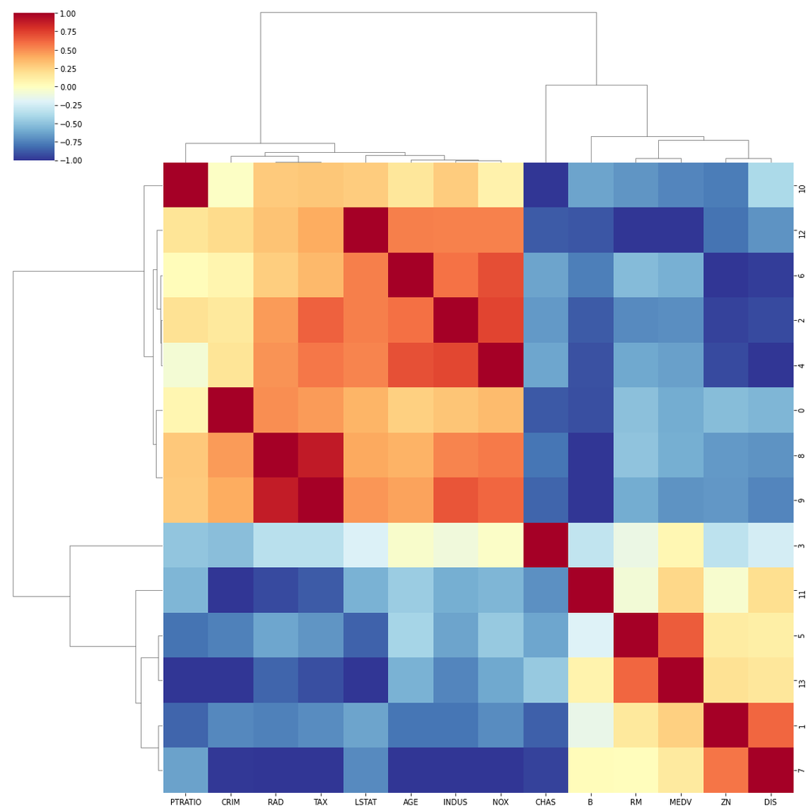

```python
from sklearn.preprocessing import MinMaxScaler
m = MinMaxScaler(feature_range=(-1,1))
data_num_minmax = m.fit_transform(boston_df.corr())
data_num_minmax = pd.DataFrame(data_num_minmax ,
                               columns=boston_df.corr().columns.tolist())
sns.clustermap(data_num_minmax,
               annot = False,
               cmap = 'RdYlBu_r',
               vmin = -1, vmax = 1,
               figsize=(15,15),
               metric="correlation"
              )
```